# What Predicts Yearly Amount Spent for Ecommerce Customers?

Below, I answer the question of how best to predict yearly amount spent on a fictional Ecommerce site. The principal predictors are the length of membership, time spent on website, time Spent on app, and average session length spent with a personal stylist. Scroll through the notebook to see what I discovered :)

## Imports

```python
import pandas as pd
import numpy as np
import matplotlib.pyplot as plt
import seaborn as sns
sns.set_style('whitegrid')
%matplotlib inline
```

## Get the Data

Fake data on ECommerce. The four chief variables are below:

- Avg. Session Length: Average session of in-store style advice sessions.
- Time on App: Average time spent on App in minutes
- Time on Website: Average time spent on Website in minutes
- Length of Membership: How many years the customer has been a member.

```python
data = pd.read_csv("Ecommerce Customers")
```

```python
data.head()
```

|  | Email | Address | Avatar | Avg. Session Length | Time on App | Time on Website | Length of Membership | Yearly Amount Spent |
| --- | --- | --- | --- | --- | --- | --- | --- | --- |
| 0 | mstephenson@fernandez.com | 835 Frank Tunnel\nWrightmouth, MI 82180-9605 | Violet | 34.497268 | 12.655651 | 39.577668 | 4.082621 | 587.951054 |
| 1 | hduke@hotmail.com | 4547 Archer Common\nDiazchester, CA 06566-8576 | DarkGreen | 31.926272 | 11.109461 | 37.268959 | 2.664034 | 392.204933 |
| 2 | pallen@yahoo.com | 24645 Valerie Unions Suite 582\nCobbborough, D... | Bisque | 33.000915 | 11.330278 | 37.110597 | 4.104543 | 487.547505 |
| 3 | riverarebecca@gmail.com | 1414 David Throughway\nPort Jason, OH 22070-1220 | SaddleBrown | 34.305557 | 13.717514 | 36.721283 | 3.120179 | 581.852344 |
| 4 | mstephens@davidson-herman.com | 14023 Rodriguez Passage\nPort Jacobville, PR 3... | MediumAquaMarine | 33.330673 | 12.795189 | 37.536653 | 4.446308 | 599.406092 |

```python
data.info()
```

```
<class 'pandas.core.frame.DataFrame'>
RangeIndex: 500 entries, 0 to 499
Data columns (total 8 columns):
Email                   500 non-null object
Address                 500 non-null object
Avatar                  500 non-null object
Avg. Session Length     500 non-null float64
Time on App             500 non-null float64
Time on Website         500 non-null float64
Length of Membership    500 non-null float64
Yearly Amount Spent     500 non-null float64
dtypes: float64(5), object(3)
memory usage: 31.3+ KB
```

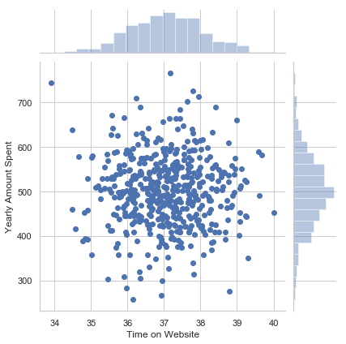

```python
sns.jointplot(x='Time on Website',y='Yearly Amount Spent',data=data)
```

## Exploratory Data Analysis

**Let's explore the data!**

For the rest of the exercise we'll only be using the numerical data of the csv file.

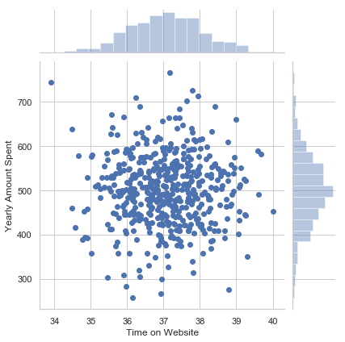

```python
%matplotlib inline
sns.jointplot(x="Time on Website",y="Yearly Amount Spent", data=data)
```

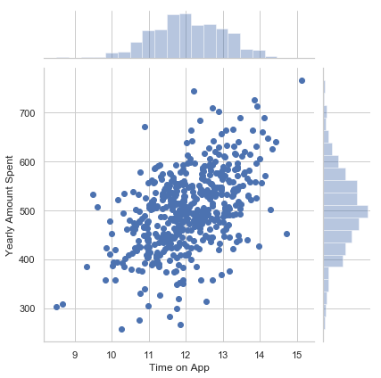

```python
%matplotlib inline
sns.jointplot(x="Time on App",y="Yearly Amount Spent", data=data)
```

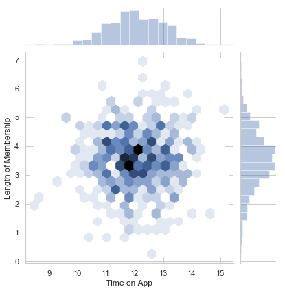

```python
sns.jointplot(x='Time on App', y='Length of Membership',data=data, kind='hex')
```

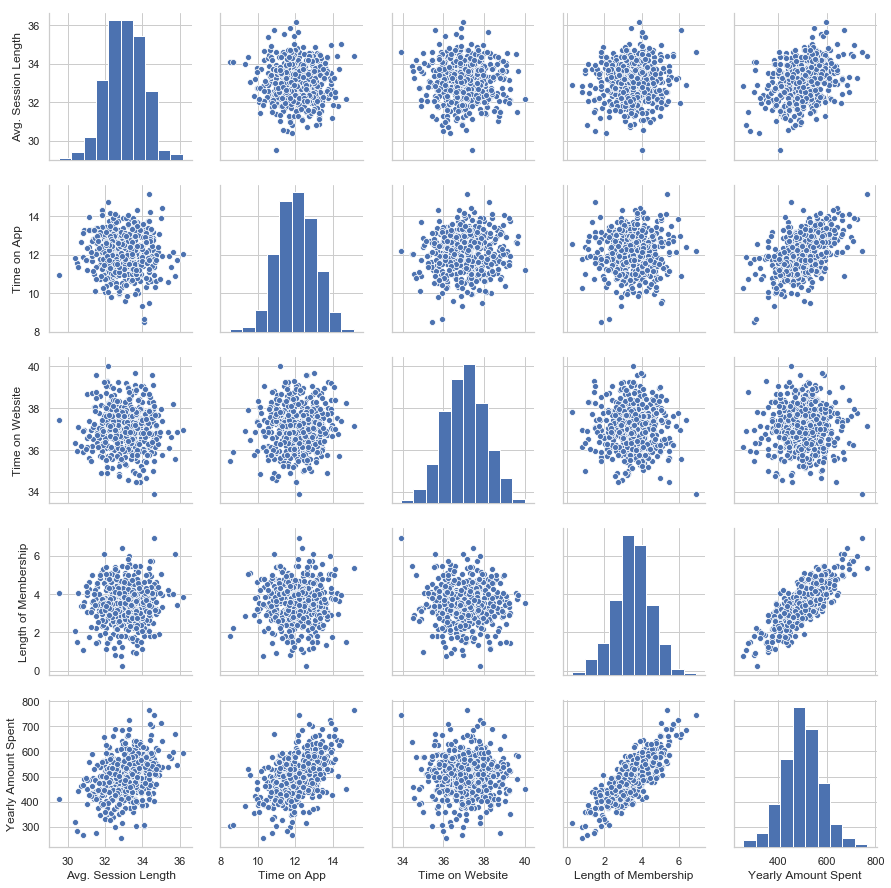

```python
sns.pairplot(data)
```

```python
#Length of membership
```

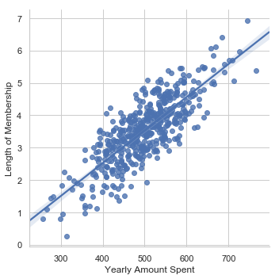

```python
sns.lmplot(x='Yearly Amount Spent',y="Length of Membership", data=data)
```

## Training and Testing Data

Now that we've explored the data a bit, let's go ahead and split the data into training and testing sets.

```python
data.columns
X = data[[ 'Avg. Session Length', 'Time on App',
       'Time on Website', 'Length of Membership']]
y = data[['Yearly Amount Spent']]
```

```python
from sklearn.model_selection import train_test_split
X_train, X_test, y_train, y_test = train_test_split(X,y,test_size=0.3,random_state=101)
```

## Training the Model

```python
from sklearn.linear_model import LinearRegression
```

```python
lm = LinearRegression()
```

```python
lm.fit(X_train,y_train)
```

```
LinearRegression(copy_X=True, fit_intercept=True, n_jobs=1, normalize=False)
```

```python
print(lm.coef_)
```

```
[[25.98154972 38.59015875  0.19040528 61.27909654]]
```

## Predicting Test Data

Now that we have fit our model, let's evaluate its performance by predicting off the test values!

```python
preds = lm.predict(X_test)
```

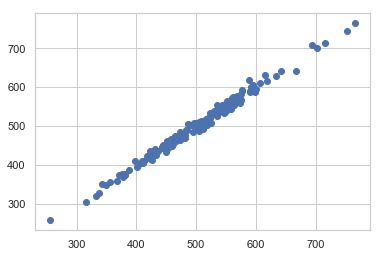

```python
plt.scatter(preds,y_test)
```

```python
from sklearn.metrics import mean_absolute_error, mean_squared_error, explained_variance_score
print('Mean absolute error: ',mean_absolute_error(preds,y_test))
print('Mean squared error: ', mean_squared_error(preds,y_test))
print('Residual mean squared error: ', np.sqrt(mean_squared_error(preds,y_test)))
print('R-squared: ',explained_variance_score(preds,y_test))
```

```
Mean absolute error:  7.22814865343082
Mean squared error:  79.81305165097419
Residual mean squared error:  8.93381506697862
R-squared:  0.9887793678920465
```

## Evaluating the Model

Let's evaluate our model performance by calculating the residual sum of squares and the explained variance score (R^2).

## Residuals

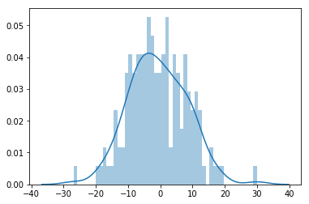

```python
sns.distplot(y_test-preds,bins=50)
```

## Conclusion

We still want to figure out the answer to the original question, do we focus our efforst on mobile app or website development? Or maybe that doesn't even really matter, and Membership Time is what is really important. Let's see if we can interpret the coefficients at all to get an idea.

```python
coeff = pd.DataFrame(lm.coef_,columns=X.columns)
coeff
```

|  | Avg. Session Length | Time on App | Time on Website | Length of Membership |
| --- | --- | --- | --- | --- |
| 0 | 25.98155 | 38.590159 | 0.190405 | 61.279097 |

### What to make of all this?

Clear from the coefficients of the linear model, the predictors length of membership and time on app have the biggest influence on yearly amount spent. If the company were to invest in either their website or app, I would suggest investing in the app to increase yearly amount spent on their platform.